# TFA exam - Guiding solution

Lars Relund Nielsen

# R - Assignment 1 (55%)

Consider the dataset in the file `catch.csv` containing catches from rivers in Denmark. A row is given for each catch with information about weight, length, date, angler, place, method etc.

Some of the columns/variables are:

- `Date`: Date of catch.
- `Length`: Length of fish (cm).
- `Weight`: Weight of fish (kilograms).
- `Place`: Place of catch (Lower, Middle, Upper).
- `Method`: Method used (Spin, Fly, Worm).
- `Killed`: If the fish was killed.
- `River`: River of catch.
- `Species`: Species of fish.
- `Name`: Name of angler.

The dataset can be read using:

```r
library(tidyverse)
dat <- read_csv("catch.csv")
```

Use the *dplyr* package in *tidyverse* to calculate relevant summary tables (tibbles/data frames), and answer/complete the following questions/tasks:

## Question 1

How many catches, different years, and different anglers are considered? What are the rivers and species considered?

```r
# load packages
library(tidyverse)
library(skimr)
res <- dat |>
   skim() |>
   print()
```

```
## ── Data Summary ────────────────────────
##                            Values
## Name                       dat
## Number of rows             29268
## Number of columns          14
## _______________________
## Column type frequency:
##   character                7
##   Date                     1
##   logical                  1
##   numeric                  5
## ________________________
## Group variables            None
##
## ── Variable type: character ──────────────────────────────────────────────────────────────
##   skim_variable n_missing complete_rate min max empty n_unique whitespace
## 1 Place                 0         1       5   6     0        3          0
## 2 Method                0         1       3   4     0        3          0
## 3 Sex               10252         0.650   4   6     0        2          0
## 4 River                 0         1       5   6     0        2          0
## 5 Species               0         1       6   8     0        2          0
## 6 Name                  0         1       7  35     0     4854          0
## 7 Weekday               0         1       6   9     0        7          0
##
## ── Variable type: Date ───────────────────────────────────────────────────────────────────
##   skim_variable n_missing complete_rate min        max        median     n_unique
## 1 Date                  0             1 2015-03-01 2023-10-31 2019-04-29     1939
##
## ── Variable type: logical ────────────────────────────────────────────────────────────────
##   skim_variable n_missing complete_rate  mean count
## 1 Killed                0             1 0.438 FAL: 16437, TRU: 12831
##
## ── Variable type: numeric ────────────────────────────────────────────────────────────────
##   skim_variable n_missing complete_rate    mean    sd      p0    p25    p50    p75   p100
## 1 Length                0         1       67.9  16.2    40      55     65     81    125
## 2 Weight            17371         0.406    3.48  2.30    0.35    1.8    2.7    4.6   19.5
## 3 Year                  0         1     2019.    2.69 2015    2016   2019   2021   2023
## 4 Month                 0         1        7.57  1.65    3       7      8      9     10
## 5 Week                  0         1       31.0   7.15    9      27     31     37     44
##   hist
## 1 ▇▇▇▂▁
## 2 ▇▃▁▁▁
## 3 ▇▆▂▆▆
## 4 ▁▂▇▆▇
## 5 ▁▂▇▇▅
```

We consider 29268 catches over 9 years. There are 4854 different anglers. The rivers considered are Karup and Skjern and the species considered are Seatrout and Salmon.

## Question 2

Given the catches, do male or female seatrout generally weigh more (on average)?

```r
res <- dat |>
   filter(Species == "Seatrout") |>
   group_by(Sex) |>
   summarize(
      avg_weight = mean(Weight, na.rm = TRUE)
   ) |>
   arrange(desc(avg_weight)) |>
   print()
```

```
## # A tibble: 3 × 2
##   Sex    avg_weight
##   <chr>       <dbl>
## 1 Male         3.18
## 2 <NA>         2.77
## 3 Female       2.67
```

On average, Male seatrout generally weigh most with an average weight of 3.18 kilograms.

## Question 3

Find the starting and ending date for all catches for each year and river. When do you expect the fishing season starts and ends for each river?

```r
res <- dat |>
   group_by(Year, River) |>
   summarize(
      start_date = min(Date),
      end_date = max(Date)
   ) |>
   arrange(River, Year) |>
   ungroup() |>
   print()
```

```
## # A tibble: 18 × 4
##     Year River  start_date end_date
##    <dbl> <chr>  <date>     <date>
##  1  2015 Karup  2015-03-01 2015-10-31
##  2  2016 Karup  2016-03-01 2016-10-31
##  3  2017 Karup  2017-03-01 2017-10-31
##  4  2018 Karup  2018-03-01 2018-10-31
##  5  2019 Karup  2019-03-01 2019-10-31
##  6  2020 Karup  2020-03-01 2020-10-31
##  7  2021 Karup  2021-03-01 2021-10-31
##  8  2022 Karup  2022-03-01 2022-10-31
##  9  2023 Karup  2023-03-01 2023-10-31
## 10  2015 Skjern 2015-04-16 2015-10-15
## 11  2016 Skjern 2016-04-16 2016-10-15
## 12  2017 Skjern 2017-04-16 2017-10-15
## 13  2018 Skjern 2018-04-16 2018-10-15
## 14  2019 Skjern 2019-04-16 2019-10-15
## 15  2020 Skjern 2020-04-16 2020-10-15
## 16  2021 Skjern 2021-04-16 2021-10-15
## 17  2022 Skjern 2022-04-16 2022-10-15
## 18  2023 Skjern 2023-04-16 2023-10-15
```

For Karup River, the fishing season to start around 2015-03-01 and ends 2015-10-31. In Skjern River, the fishing season starts around 2015-04-16 and ends 2015-10-15.

## Question 4

Consider the data from Karup River after 2019. How may anglers have at least one year caught and killed more than 20 kilograms of fish?

```r
res <- dat |>
   filter(River == "Karup", Year >= 2020) |>
   group_by(Year, Name) |>
   summarize(
      total_weight = sum(Weight),
      n_killed = sum(Killed)
   ) |>
   filter(total_weight > 20) |>
   ungroup() |>
   arrange(Name, Year) |>
   print()
```

```
## # A tibble: 15 × 4
##     Year Name                       total_weight n_killed
##    <dbl> <chr>                             <dbl>    <int>
##  1  2023 Anette Jespersen                   43.6       16
##  2  2021 Børge Jespersen                    21.4        5
##  3  2022 Børge Jespersen                    31.0        6
##  4  2022 Carlo Mogensen                     24.3        6
##  5  2020 Fru Sussanne Rasmussen             47.0        9
##  6  2020 Fru Vivian Lund                    29         11
##  7  2020 Kenny Mortensen                    23.6        6
##  8  2020 Mille Andersen-Winther             26.4        7
##  9  2020 Pete Skov-Holm                     21.6        7
## 10  2022 Prof. Michelle Bertelsen           32.8       10
## 11  2023 Prof. Michelle Bertelsen           35.1       14
## 12  2020 Steven Winther                     24          8
## 13  2020 Univ.Prof. Freddy Jakobsen         35.4       14
## 14  2020 Univ.Prof. Ivan Klausen            24.2        7
## 15  2022 Åge Ravn-Overgaard                 25.2        8
```

```r
res2 <- res |>
   distinct(Name) |>
   summarise(n = n()) |>
   print()
```

```
## # A tibble: 1 × 1
##       n
##   <int>
## 1    13
```

There are 13 anglers that in one year have caught and killed more than 20 kilograms of fish in Karup River after 2019.

## Question 5

For each year and river, calculate the total number of fish caught, as well as the average and maximum length. For each river, what is the best season in terms of the number of fish caught?

```r
res <- dat |>
   group_by(Year, River) |>
   summarize(
      n_caught = n(),
      avg_length = mean(Length),
      max_length = max(Length)
   ) |>
   arrange(River, desc(n_caught)) |>
   ungroup() |>
   print()
```

```
## # A tibble: 18 × 5
##     Year River  n_caught avg_length max_length
##    <dbl> <chr>     <int>      <dbl>      <dbl>
##  1  2015 Karup      2359       58.6       96
##  2  2016 Karup      1630       60.5      102
##  3  2020 Karup      1224       60.0       97
##  4  2023 Karup      1091       56.9       93
##  5  2017 Karup      1090       58.7       91
##  6  2021 Karup       985       56.9       92
##  7  2018 Karup       756       57.9       97.5
##  8  2022 Karup       751       60.3       91
##  9  2019 Karup       665       57.8       92
## 10  2015 Skjern     2623       66.5      115
## 11  2022 Skjern     2243       76.1      124
## 12  2018 Skjern     2231       70.6      122
## 13  2020 Skjern     2099       74.0      123
## 14  2019 Skjern     2019       77.9      124
## 15  2017 Skjern     1964       78.6      122
## 16  2023 Skjern     1917       70.5      124
## 17  2016 Skjern     1860       69.8      125
## 18  2021 Skjern     1761       74.8      122
```

For Karup River, the best season in terms of number of fish caught is 2015 with 2359 fish caught. For Skjern River, the best season is 2015 with 2623 fish caught.

What is the average length of the longest fish caught each year in Skjern River?

```r
res2 <- res |>
   filter(River == "Skjern") |>
   summarize(
      avg_length_max_fish = mean(max_length)
   ) |>
   print()
```

```
## # A tibble: 1 × 1
##   avg_length_max_fish
##                 <dbl>
## 1                122.
```

The average length of the biggest fish caught in Skjern River over all years is 122.33 cm.

## Question 6

For each river, year, and month, calculate the cumulative number (absolute and in percentages) of fish caught over the year (ordered by month). Has the percentage of fish caught before August in Karup River increased over the years? Hint: Given a group, the `cumsum` function can be used to add all values up to and including the current row.

```r
res <- dat |>
   group_by(River, Year, Month) |>
   summarize(
      n_caught = n()
   ) |>
   arrange(River, Year, Month) |>
   group_by(River, Year) |>
   mutate(cum_n_caught = cumsum(n_caught),
          cum_n_caught_pct = cum_n_caught / sum(n_caught)
             ) |>
   ungroup() |>
   print()
```

```
## # A tibble: 135 × 6
##    River  Year Month n_caught cum_n_caught cum_n_caught_pct
##    <chr> <dbl> <dbl>    <int>        <int>            <dbl>
##  1 Karup  2015     3       88           88           0.0373
##  2 Karup  2015     4       15          103           0.0437
##  3 Karup  2015     5       40          143           0.0606
##  4 Karup  2015     6      182          325           0.138
##  5 Karup  2015     7      755         1080           0.458
##  6 Karup  2015     8      627         1707           0.724
##  7 Karup  2015     9      328         2035           0.863
##  8 Karup  2015    10      324         2359           1
##  9 Karup  2016     3      128          128           0.0785
## 10 Karup  2016     4       18          146           0.0896
## # ℹ 125 more rows
```

```r
res2 <- res |>
   filter(River == "Karup", Month == 7) |>
   select(Year, cum_n_caught_pct) |>
   arrange(Year) |>
   print()
```

```
## # A tibble: 9 × 2
##    Year cum_n_caught_pct
##   <dbl>            <dbl>
## 1  2015            0.458
## 2  2016            0.571
## 3  2017            0.606
## 4  2018            0.310
## 5  2019            0.414
## 6  2020            0.522
## 7  2021            0.357
## 8  2022            0.465
## 9  2023            0.389
```

For Karup River, the percentage of fish caught before August don’t seem to have increased over the years as the values are: 45.78, 57.12, 60.55, 30.95, 41.35, 52.21, 35.74, 46.47, 38.86 for the years 2015, 2016, 2017, 2018, 2019, 2020, 2021, 2022, 2023.

# R - Assignment 2 (45%)

Answer this assignment using the *ggplot2* package in *tidyverse* (you may need *dplyr* for preparing the datasets you want to plot). We use the same dataset as given in Assignment 1 if not specified.

## Question 1

Create a visualization showing the total number of salmon caught in Skjern River over the years with the following features:

- Bars with the fill color steelblue are used.
- An informative figure title and axis titles are given.

Which year has the highest number of salmon caught in Skjern River?

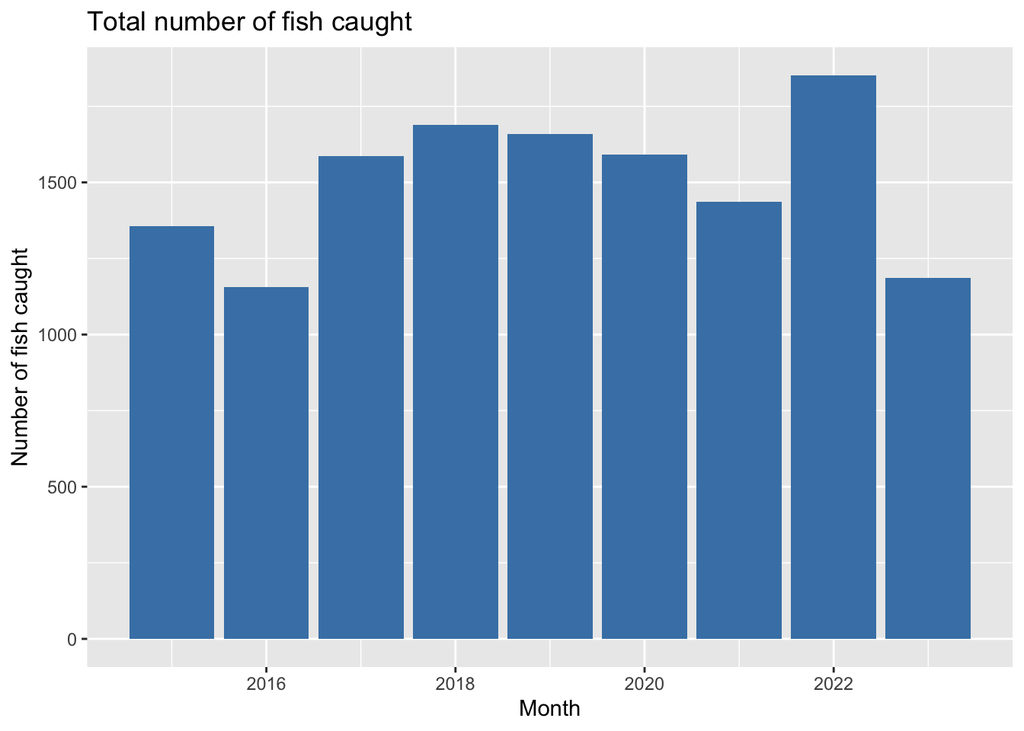

```r
dat |>
   filter(River == "Skjern", Species == "Salmon") |>
   ggplot(aes(x = Year)) +
   geom_bar(fill = "steelblue") +
   labs(
      title = "Total number of fish caught",
      x = "Month",
      y = "Number of fish caught"
   )
```

The year with the highest number of salmon caught in Skjern River is 2022.

## Question 2

Create a visualization showing the weight of fish caught in each river over the weeks with the following features:

- Points are used to show the weight given week with a 0.5 size.
- A trend line is added to show the trend over weeks.
- Different colours are used for each river.
- A subplot is used for each species.
- An informative figure title and axis titles are given.
- The legend is placed at the bottom of the figure.

Is the average weight of fish in general higher in the beginning of the season?

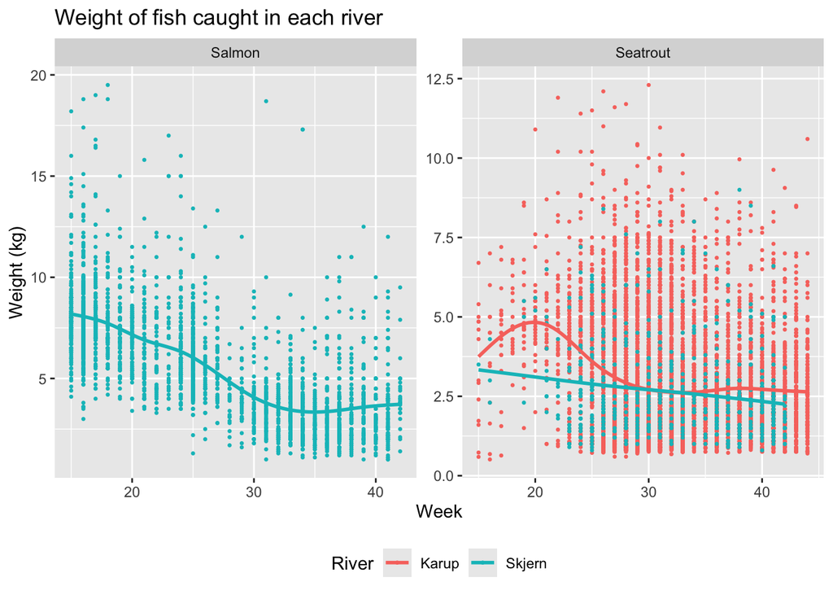

```r
dat |>
   filter(Week >= 15) |>
   ggplot(aes(x = Week, y = Weight, color = River)) +
   geom_point(size = 0.5) +
   geom_smooth(se = FALSE) +
   facet_wrap(~Species, scales = "free") +
   labs(
      title = "Weight of fish caught in each river",
      x = "Week",
      y = "Weight (kg)"
   ) +
   theme(legend.position = "bottom")
```

## Question 3

Consider seatrout caught in Skjern River in 2020 and 2023. Create a visualization showing the proportion of catches over the months with the following features:

- Bars are used to visualize the proportion of catches per place (all bars have the same height).
- Different fill colours are used for each place.
- A subplot is made for each year.
- An informative figure title and axis titles are given.
- The legend is placed at the bottom of the figure.

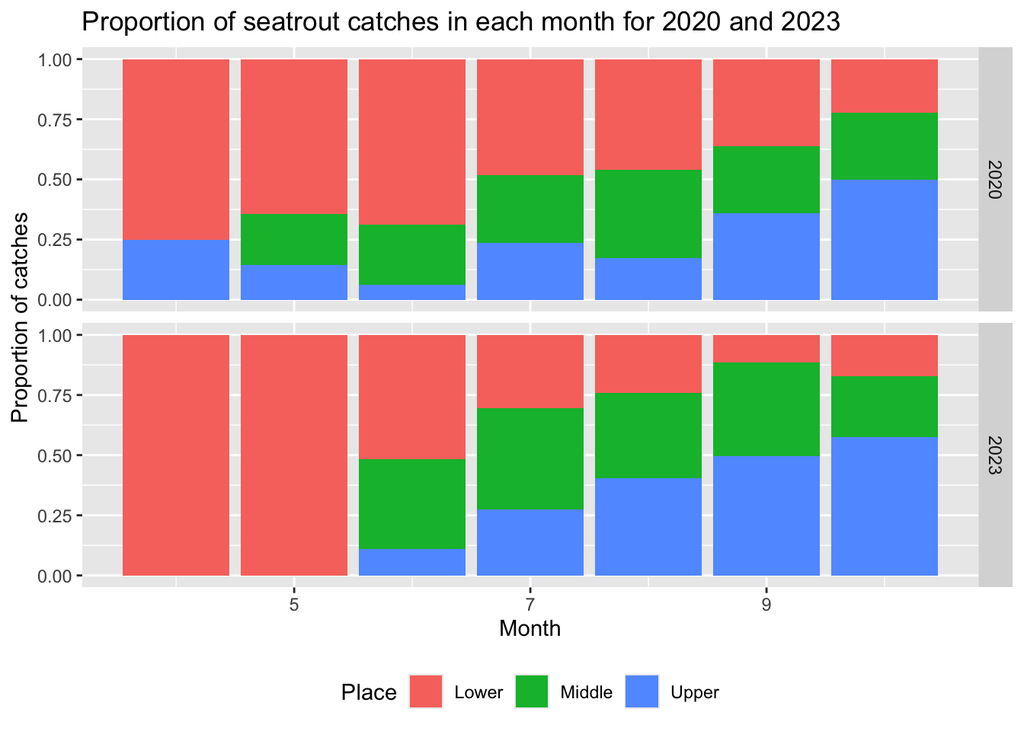

```r
dat |>
   filter(River == "Skjern", Species == "Seatrout") |>
   filter(Year %in% c(2020, 2023)) |>
   ggplot(aes(x = Month, fill = Place)) +
   geom_bar(position = "fill") +
   facet_grid(Year~.) +
   labs(
      title = "Proportion of seatrout catches in each month for 2020 and 2023",
      x = "Month",
      y = "Proportion of catches"
   ) +
   theme(legend.position = "bottom")
```

## Question 4

Consider a dataset with water level measurements given in the file `waterlevel.csv`. The dataset can be read using:

```r
library(tidyverse)
dat_wl <- read_csv("waterlevel.csv")
```

The dataset contains daily water level measurements from two places in Karup River in 2023. The water levels are given as deviations (in cm) from the mean water level for the place (same year). The columns/variables are:

- `Date`: Date of measurement.
- `Waterlevel`: Water level deviation from mean (cm).
- `River`: River of measurement.
- `Place`: Place of measurement.

Create a visualization showing the water level over the dates with the following features:

- A line plot is used to show the water level.
- Different colours are used for each place.
- An informative figure title and axis titles are given.
- The legend is placed at the bottom of the figure.

How is the water level in general increasing/decreasing over the year?

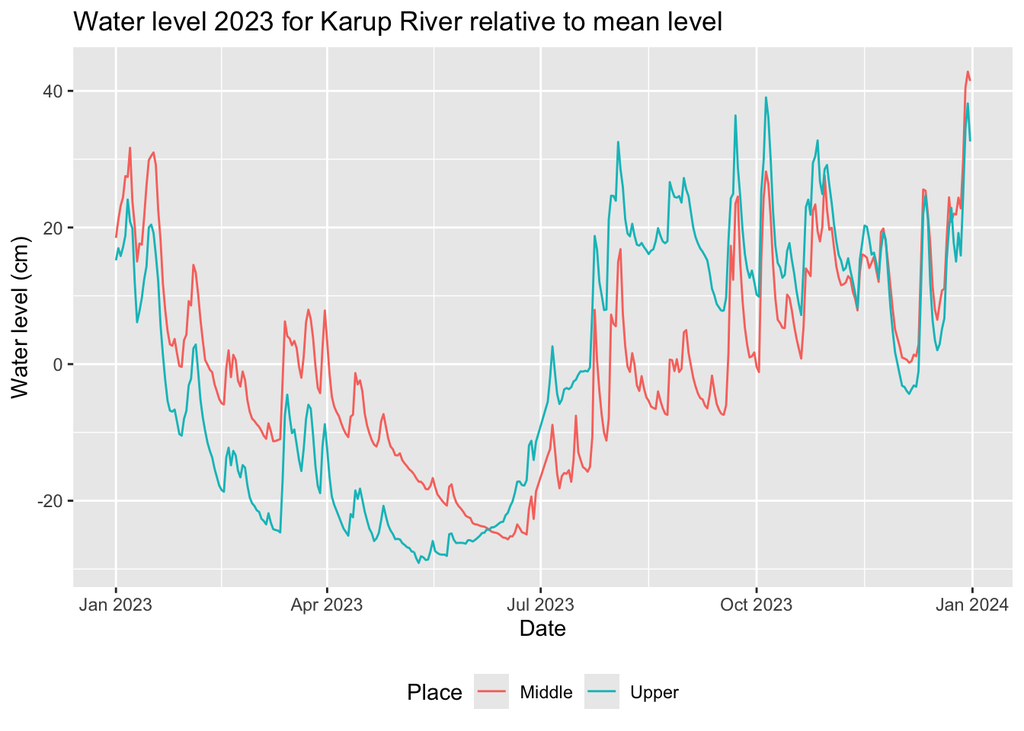

```r
dat_wl |>
   ggplot(aes(x = Date, y = Waterlevel, color = Place)) +
   geom_line() +
   labs(
      title = "Water level 2023 for Karup River relative to mean level",
      x = "Date",
      y = "Water level (cm)"
   ) +
   theme(legend.position = "bottom")
```

In general, the water level is decreasing until approx. mid June and then increasing over the rest of the year.

## Question 5

Consider only the water levels in the middle part of the Karup River and observations from March to October 2023. Calculate the trend of the water level compared to last day (i.e. the difference between the current day and the last day). Next, classify the trend into three categories:

- “Increasing” if the water level has increased by more than 1 cm compared to the last day.
- “Decreasing” if the water level has decreased by more than 1 cm compared to the last day.
- “None” if the water level change is between -1 cm and 1 cm compared to the last day.

Hint: Note you can use the `lag` function to retrieve the value in the previous row.

```r
res <- dat_wl |>
   filter(Place == "Middle", Date >= "2023-03-01", Date <= "2023-10-31") |>
   group_by(River, Place) |>
   arrange(Date) |>
   mutate(
      trend = Waterlevel - lag(Waterlevel, n = 1),
      trend = if_else(is.na(trend), 0, trend),
      trend_num = trend,
      trend = case_when(
         trend > 1 ~ "Increasing",
         trend < -1 ~ "Decreasing",
         TRUE ~ "None"
      )
   ) |>
   ungroup() |>
   arrange(River, Place, Date) |>
   print()
```

```
## # A tibble: 241 × 6
##    Date       River Place  Waterlevel trend      trend_num
##    <date>     <chr> <chr>       <dbl> <chr>          <dbl>
##  1 2023-03-01 Karup Middle      -8.32 None          0
##  2 2023-03-02 Karup Middle      -8.80 None         -0.482
##  3 2023-03-03 Karup Middle      -9.18 None         -0.376
##  4 2023-03-04 Karup Middle      -9.77 None         -0.593
##  5 2023-03-05 Karup Middle     -10.5  None         -0.729
##  6 2023-03-06 Karup Middle     -10.9  None         -0.425
##  7 2023-03-07 Karup Middle      -8.67 Increasing    2.26
##  8 2023-03-08 Karup Middle      -9.81 Decreasing   -1.15
##  9 2023-03-09 Karup Middle     -11.3  Decreasing   -1.47
## 10 2023-03-10 Karup Middle     -11.3  None          0.0359
## # ℹ 231 more rows
```

Create a visualization showing the variation in water levels with the following features:

- A density is used to show the distribution of water levels given the trend category.
- Different fill colours are used for each trend category.
- Transparency is used to see overlapping areas.
- An informative figure title and axis titles are given.
- The legend is placed at the bottom of the figure.

Which trend category seems to be the most dominant one when the water levels are low?

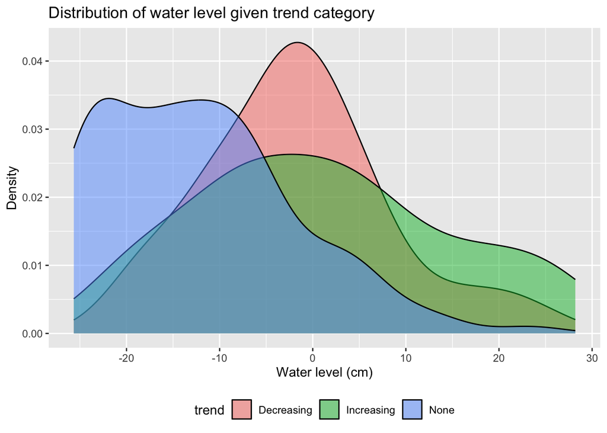

```r
res |>
   ggplot(aes(x = Waterlevel, fill = trend)) +
   geom_density(alpha = 0.5) +
   labs(
      title = "Distribution of water level given trend category",
      x = "Water level (cm)",
      y = "Density"
   ) +
   theme(legend.position = "bottom")
```

When low water levels, the “None” trend category seems to be the most dominant as seen from the figure. That is, when the water level is low, it most of the time tends to be stable and not changing much from day to day.